# Homework 2

Jintao Liu

Feb 20, 2018

```r
knitr::opts_chunk$set(echo = TRUE,warning=FALSE,message=FALSE)

library(boot);library(tidyverse)
```

# Chapter 5

### Question 9

```r
Boston <- MASS::Boston
muhat <- mean(Boston$medv)
```

$\hat{\mu}$ = 22.533

```r
sehat <- sd(Boston$medv)/sqrt(length(Boston$medv))
```

*SE*($\hat{\mu}$) = 0.409

```r
spmedv <- function(data,index) return(coef(lm(medv~1,data=data,subset=index)))

boot(data = Boston,statistic = spmedv,R = 1000)
```

```
##
## ORDINARY NONPARAMETRIC BOOTSTRAP
##
##
## Call:
## boot(data = Boston, statistic = spmedv, R = 1000)
##
##
## Bootstrap Statistics :
##     original     bias    std. error
## t1* 22.53281 0.02472767   0.3952698
```

The estimate of SE(medv) is very close to the answer from b.

```r
paste("95% CI = ","[",round(muhat-2*sehat,2),", ",round(muhat+2*sehat,2),"]",sep = "")
```

```
## [1] "95% CI = [21.72, 23.35]"
```

```r
t <- t.test(Boston$medv)
attributes(t$conf.int)<-NULL
t$conf.int
```

```
## [1] 21.72953 23.33608
```

So the bootstrap method gives very close results as from the t test.

$\hat{\mu}$<sub>med</sub> = 21.2

```r
samplemedian <- function(x, d) return(median(x[d]))
boot(Boston$medv, samplemedian, R=1000)
```

```
##
## ORDINARY NONPARAMETRIC BOOTSTRAP
##
##
## Call:
## boot(data = Boston$medv, statistic = samplemedian, R = 1000)
##
##
## Bootstrap Statistics :
##     original   bias    std. error
## t1*     21.2 -0.01105   0.3801248
```

```r
quantile(Boston$medv,0.9)
```

```
##  90%
## 34.8
```

```r
tenth <- function(x, d) return(quantile(x[d],0.9))
boot(Boston$medv, tenth, R=1000)
```

```
##
## ORDINARY NONPARAMETRIC BOOTSTRAP
##
##
## Call:
## boot(data = Boston$medv, statistic = tenth, R = 1000)
##
##
## Bootstrap Statistics :
##     original  bias    std. error
## t1*     34.8 -0.3308    1.142029
```

# Chapter 6

## Question 9

```r
set.seed(666)

college <- read.csv("college.csv")
college <- college[,-1]
college$id <- 1:nrow(college)

id.train<-sample(1:nrow(college),replace = FALSE,size = 500)

train <- college[college$id %in% id.train,]
test <-  college[-which(college$id %in% id.train),]

train <- train[,!names(train)%in%"id"]
test <-  test[,!names(test)%in%"id"]
```

```r
library(leaps)
sub.fit <- regsubsets(Apps~.,data=train,nvmax = 19                      )
sub.summ <- summary(sub.fit)
```

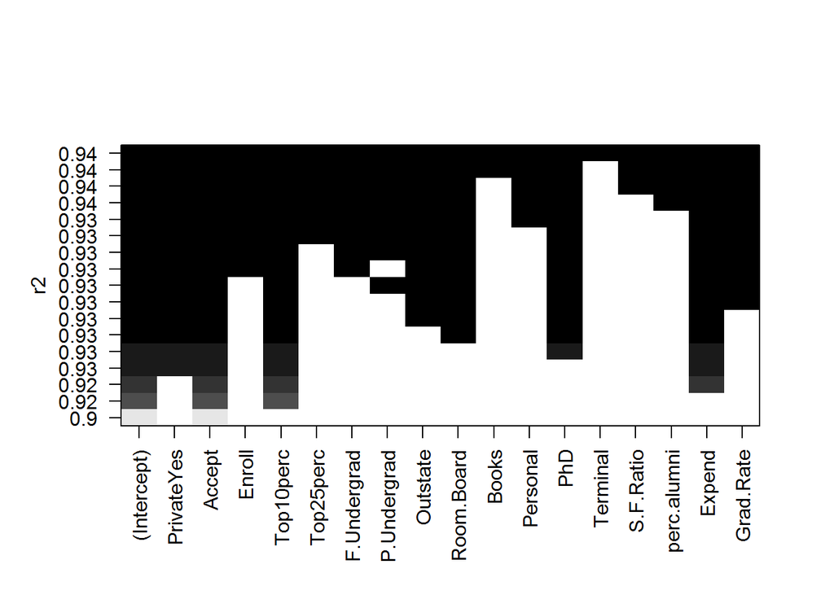

```r
plot(sub.fit ,scale ="r2")
```

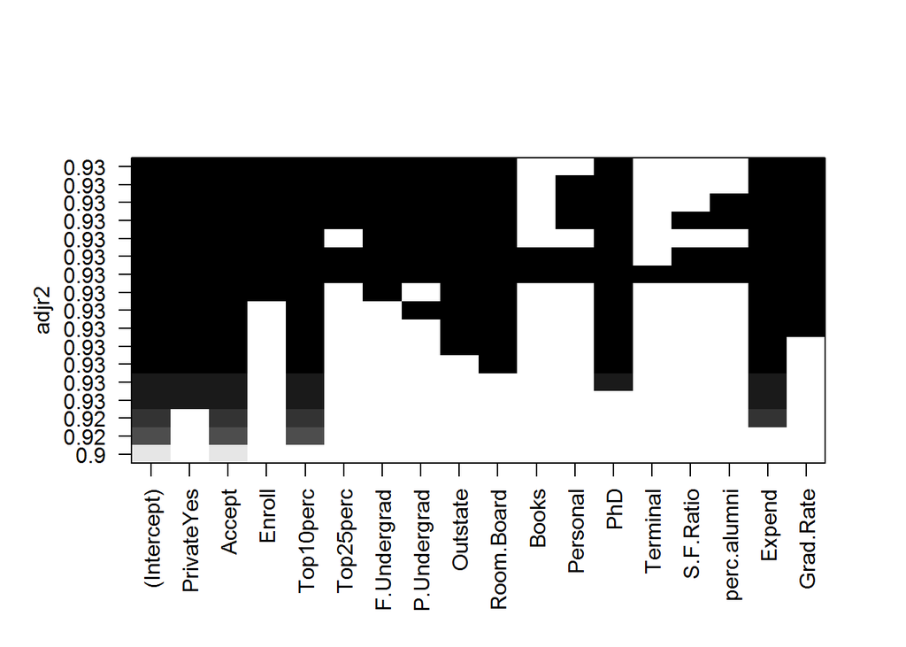

```r
plot(sub.fit ,scale ="adjr2")
```

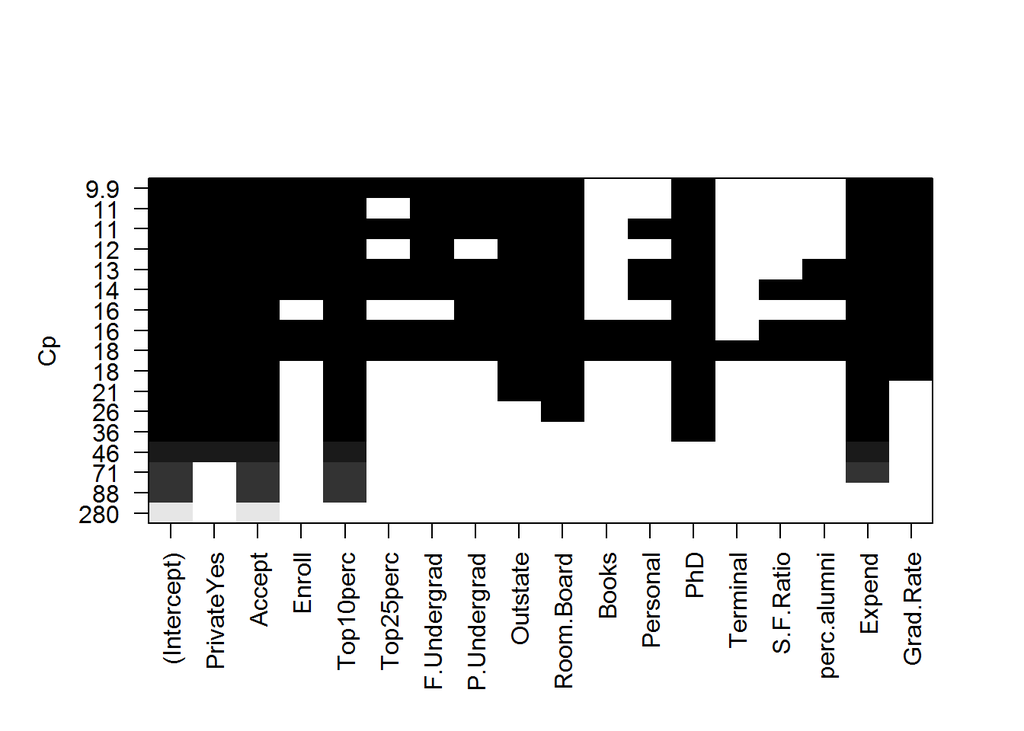

```r
plot(sub.fit ,scale ="Cp")
```

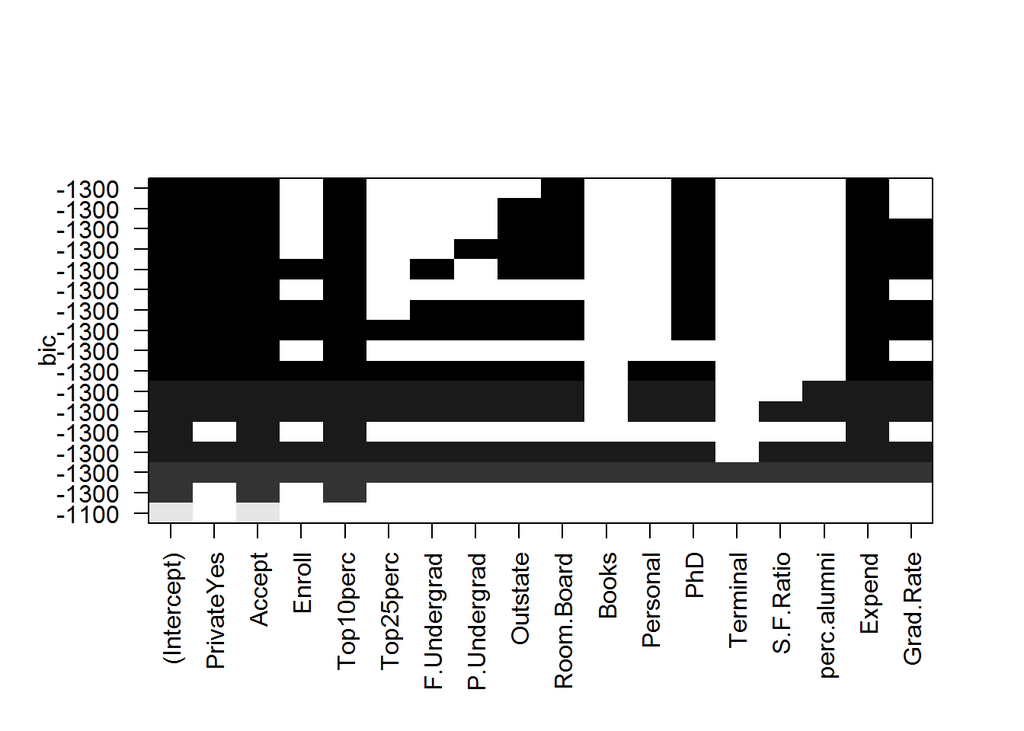

```r
plot(sub.fit ,scale ="bic")
```

The model with lowest BIC is the model containing 6 variables, including:

```r
coef(sub.fit,6)
```

```
##   (Intercept)    PrivateYes        Accept     Top10perc    Room.Board
## -190.65756701 -809.59926279    1.34235085   30.20938984    0.15661191
##           PhD        Expend
##  -12.97915244    0.04813832
```

```r
leastvar <- names(coef(sub.fit,10))[-1]
leastvar[1]<-"Private"
```

```r
b <- paste(leastvar,collapse="+")
linear <- lm(paste("Apps~",b,sep=""),data=college)
summary(linear)
```

```
##
## Call:
## lm(formula = paste("Apps~", b, sep = ""), data = college)
##
## Residuals:
##     Min      1Q  Median      3Q     Max
## -4828.9  -440.7   -22.7   316.5  7943.1
##
## Coefficients:
##               Estimate Std. Error t value Pr(>|t|)
## (Intercept) -426.46223  251.90081  -1.693 0.090866 .
## PrivateYes  -523.96427  135.09523  -3.878 0.000114 ***
## Accept         1.57324    0.04014  39.193  < 2e-16 ***
## Enroll        -0.84908    0.18492  -4.592 5.14e-06 ***
## Top10perc     34.96193    3.30054  10.593  < 2e-16 ***
## F.Undergrad    0.06312    0.03139   2.011 0.044698 *
## Outstate      -0.09275    0.01843  -5.033 6.03e-07 ***
## Room.Board     0.15638    0.04699   3.328 0.000918 ***
## PhD          -11.89187    3.10031  -3.836 0.000136 ***
## Expend         0.08092    0.01122   7.213 1.32e-12 ***
## Grad.Rate      7.14324    2.83496   2.520 0.011948 *
## ---
## Signif. codes:  0 '***' 0.001 '**' 0.01 '*' 0.05 '.' 0.1 ' ' 1
##
## Residual standard error: 1047 on 766 degrees of freedom
## Multiple R-squared:  0.9278, Adjusted R-squared:  0.9268
## F-statistic: 983.9 on 10 and 766 DF,  p-value: < 2.2e-16
```

```r
mean((test$Apps - predict.lm(linear, test)) ^ 2)
```

```
## [1] 1586524
```

MSE for test is 1586524.

3. Ridge regression

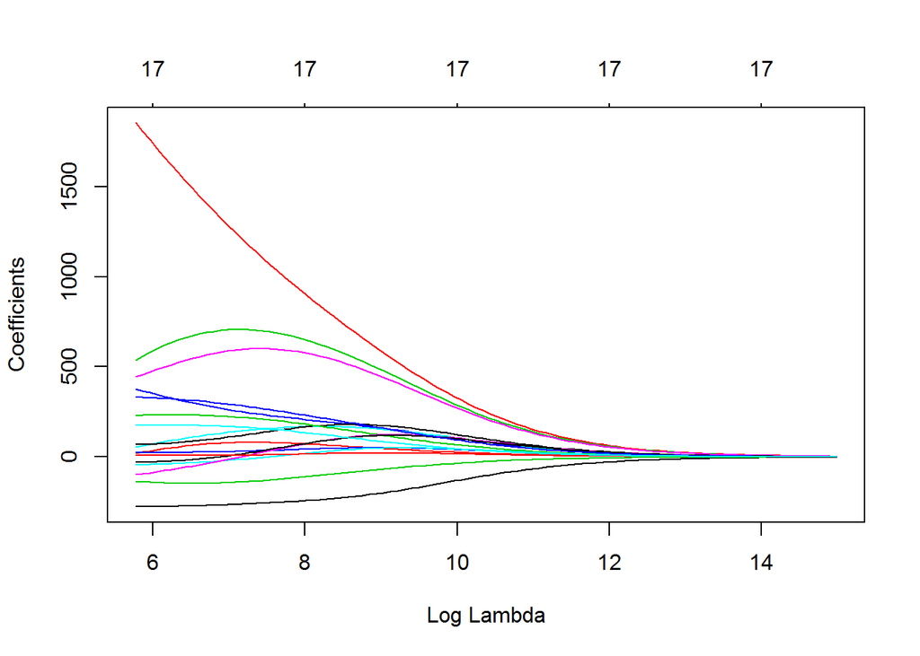

```r
set.seed(666)
library(glmnet)

x <- model.matrix(Apps ~ ., train)[,-1]
x.test <- model.matrix(Apps ~ ., test)[,-1]
y <- train$Apps
x <- scale(x)

ridge.mod <- glmnet(x, y, alpha=0)

plot(ridge.mod, xvar='lambda')
```

```r
## cross-validation
cv.out <- cv.glmnet(x, y, alpha=0, lambda=exp(seq(0, 20, 0.05)))

ridge.pred <- predict(ridge.mod, s=cv.out$lambda.min, newx=x.test) # prediction
mean((ridge.pred -test$Apps)^2)
```

```
## [1] 1.791044e+14
```

This is a very large test MSE.

4. LASSO

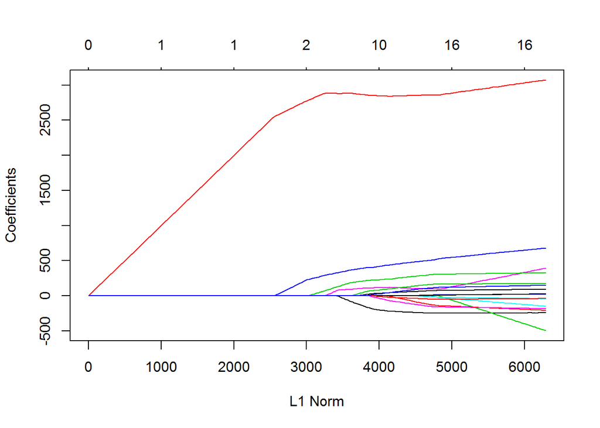

```r
set.seed(666)
lasso.mod <-glmnet (x,y,alpha =1, lambda =exp(seq(0, 20, 0.05)))
plot(lasso.mod)
```

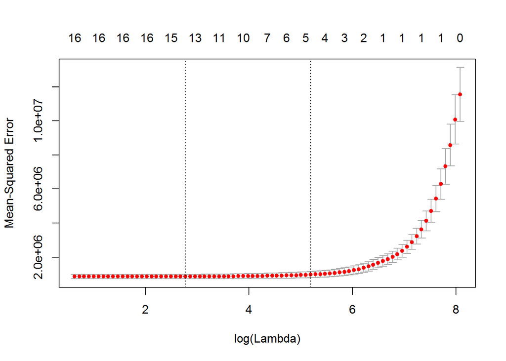

```r
cv.out <- cv.glmnet (x,y,alpha =1)
plot(cv.out)
```

```r
bestlam <- cv.out$lambda.min
lasso.pred <- predict(lasso.mod,s=bestlam ,newx=x.test)
mean((lasso.pred-test$Apps)^2)
```

```
## [1] 1.591758e+14
```

```r
out=glmnet(x,y,alpha =1, lambda =exp(seq(0, 20, 0.05)))
lasso.coef=predict(out ,type ="coefficients",s=bestlam )[1:18,]
lasso.coef
```

```
##  (Intercept)   PrivateYes       Accept       Enroll    Top10perc
## 2805.5820000 -244.2265304 2855.2069501    0.0000000  499.7125449
##    Top25perc  F.Undergrad  P.Undergrad     Outstate   Room.Board
##    0.0000000   99.8458947   69.4538985 -114.4498082  157.2692569
##        Books     Personal          PhD     Terminal    S.F.Ratio
##    8.8518619  -10.5147888 -144.2852900    0.0000000    0.6332165
##  perc.alumni       Expend    Grad.Rate
##  -45.1369230  293.8233865  106.5468318
```

```r
sum(lasso.coef!=0)
```

```
## [1] 15
```

5. PCR

```r
library(pls)
set.seed (666)
pcr.fit<-pcr(Apps~., data=train ,scale=TRUE ,validation ="CV")
summary(pcr.fit)
```

```
## Data:    X dimension: 500 17
##  Y dimension: 500 1
## Fit method: svdpc
## Number of components considered: 17
##
## VALIDATION: RMSEP
## Cross-validated using 10 random segments.
##        (Intercept)  1 comps  2 comps  3 comps  4 comps  5 comps  6 comps
## CV            3413     3344     1661     1657     1362     1274     1257
## adjCV         3413     3344     1659     1655     1356     1270     1253
##        7 comps  8 comps  9 comps  10 comps  11 comps  12 comps  13 comps
## CV        1189     1179     1133      1141      1136      1143      1146
## adjCV     1178     1171     1129      1138      1133      1141      1144
##        14 comps  15 comps  16 comps  17 comps
## CV         1149      1142     962.2     939.3
## adjCV      1146      1143     959.1     935.4
##
## TRAINING: % variance explained
##       1 comps  2 comps  3 comps  4 comps  5 comps  6 comps  7 comps
## X      31.116    56.59    63.65    69.88    75.21    80.19    83.90
## Apps    5.074    77.02    77.23    85.26    86.76    87.45    89.13
##       8 comps  9 comps  10 comps  11 comps  12 comps  13 comps  14 comps
## X       87.36    90.34     92.91     95.09     96.98     98.09     98.86
## Apps    89.14    89.60     89.62     89.74     89.75     89.82     89.83
##       15 comps  16 comps  17 comps
## X        99.38     99.84    100.00
## Apps     90.12     92.88     93.51
```

Although the lowest CV score occurs at M=17, which is the full components that is not useful, there is a locally minimal CV score=1133 when M=9.

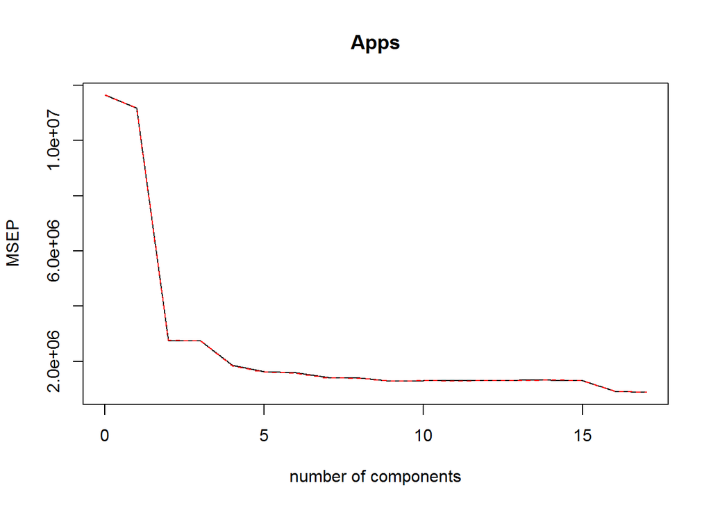

```r
validationplot(pcr.fit ,val.type="MSEP")
```

```r
pcr.pred <- predict(pcr.fit, x.test, ncomp =9)
mean((pcr.pred -test$Apps)^2)
```

```
## [1] 3779697
```

PCR generated a test MSE of 3779697. Compared to the MSE from linear regression, 3779697-1586524=2.19317310^{6}, it didn’t win over linear regression. But it is much better than shrinkage methods.

6. PLS

```r
set.seed(666)
pls.fit <- plsr(Apps~., data=train ,scale=TRUE ,validation ="CV")
summary(pls.fit)
```

```
## Data:    X dimension: 500 17
##  Y dimension: 500 1
## Fit method: kernelpls
## Number of components considered: 17
##
## VALIDATION: RMSEP
## Cross-validated using 10 random segments.
##        (Intercept)  1 comps  2 comps  3 comps  4 comps  5 comps  6 comps
## CV            3413     1487     1239     1105     1068   1005.6    959.9
## adjCV         3413     1483     1241     1103     1063    997.4    955.3
##        7 comps  8 comps  9 comps  10 comps  11 comps  12 comps  13 comps
## CV       944.6      941    942.9     946.0     942.5     939.1     939.2
## adjCV    941.5      938    939.4     942.1     938.5     935.2     935.3
##        14 comps  15 comps  16 comps  17 comps
## CV        939.2     939.2     939.4     939.3
## adjCV     935.4     935.3     935.5     935.4
##
## TRAINING: % variance explained
##       1 comps  2 comps  3 comps  4 comps  5 comps  6 comps  7 comps
## X       25.85    43.36    62.33    66.07    68.74    72.94    77.75
## Apps    81.84    87.58    90.24    91.39    92.73    93.20    93.29
##       8 comps  9 comps  10 comps  11 comps  12 comps  13 comps  14 comps
## X       81.19    83.28     86.27     89.09     90.77     92.76     94.61
## Apps    93.35    93.42     93.46     93.50     93.51     93.51     93.51
##       15 comps  16 comps  17 comps
## X        96.97     98.80    100.00
## Apps     93.51     93.51     93.51
```

```r
pls.pred <- predict(pls.fit ,x.test, ncomp =13)
mean((pls.pred -test$Apps)^2)
```

```
## [1] 1758650
```

This test MSE is the most closed one to the linear regression but still higher by 1758650-1586524=1.7212610^{5}.

7. Comments

In conclusion, for this college dataset, ridge, the Lasso, PCR and PLS didn’t win over best subset method. Particularly, shrinkage methods produced much higher test MSE than other methods, because the lambda chosen by these two methods didn’t put large penalty on the number of predictors, resulting in a model close to the full model.

## Question 11

```r
set.seed(666)
Boston <- MASS::Boston
Boston$id <- 1:nrow(Boston)
id.train<-sample(1:nrow(Boston),replace = FALSE,size = 300)

train <- Boston[Boston$id %in% id.train,]
test <-  Boston[-which(Boston$id %in% id.train),]

train <- train[,!names(train)%in%"id"]
test <-  test[,!names(test)%in%"id"]
```

```r
#Kitchen sink model:
summary(lm(crim~.,data=train))
```

```
##
## Call:
## lm(formula = crim ~ ., data = train)
##
## Residuals:
##    Min     1Q Median     3Q    Max
## -9.830 -1.865 -0.264  1.009 72.977
##
## Coefficients:
##              Estimate Std. Error t value Pr(>|t|)
## (Intercept)  7.542655  10.221479   0.738   0.4612
## zn           0.045624   0.026051   1.751   0.0810 .
## indus       -0.041006   0.119277  -0.344   0.7313
## chas        -1.397975   1.710851  -0.817   0.4145
## nox         -4.936258   7.645312  -0.646   0.5190
## rm           1.411517   0.882891   1.599   0.1110
## age         -0.012532   0.024808  -0.505   0.6138
## dis         -0.887945   0.372762  -2.382   0.0179 *
## rad          0.634526   0.120921   5.247 3.01e-07 ***
## tax         -0.006607   0.007116  -0.928   0.3539
## ptratio     -0.253891   0.256528  -0.990   0.3231
## black       -0.002956   0.005515  -0.536   0.5924
## lstat        0.186193   0.110870   1.679   0.0942 .
## medv        -0.254389   0.090734  -2.804   0.0054 **
## ---
## Signif. codes:  0 '***' 0.001 '**' 0.01 '*' 0.05 '.' 0.1 ' ' 1
##
## Residual standard error: 6.847 on 286 degrees of freedom
## Multiple R-squared:  0.4384, Adjusted R-squared:  0.4129
## F-statistic: 17.17 on 13 and 286 DF,  p-value: < 2.2e-16
```

```r
library(leaps)
sub.fit <- regsubsets(crim~.,data=train,nvmax = 13)
sub.summ <- summary(sub.fit)
```

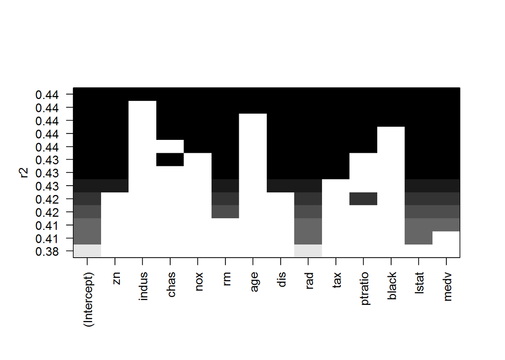

```r
plot(sub.fit ,scale ="r2")
```

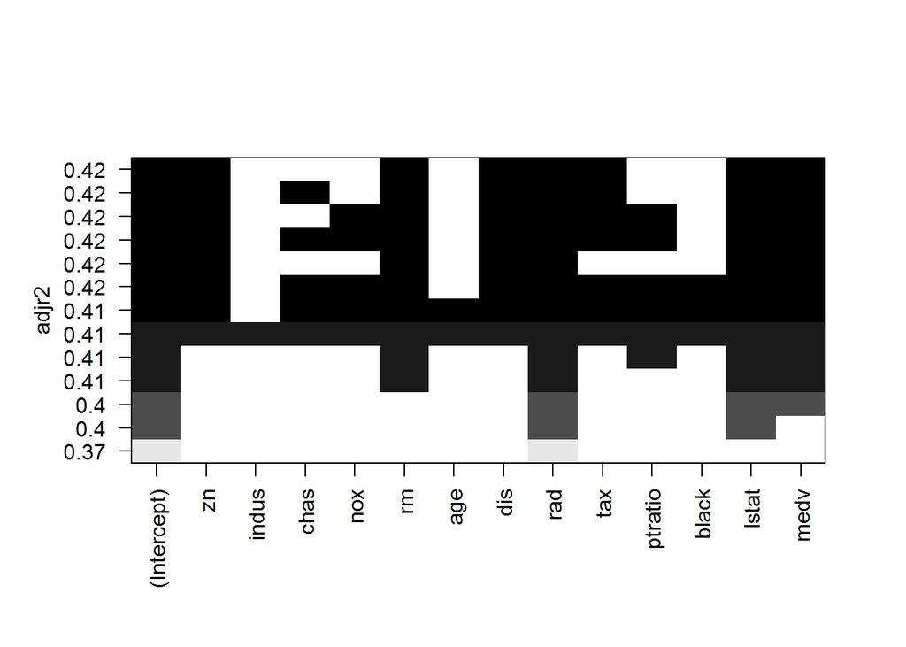

```r
plot(sub.fit ,scale ="adjr2")
```

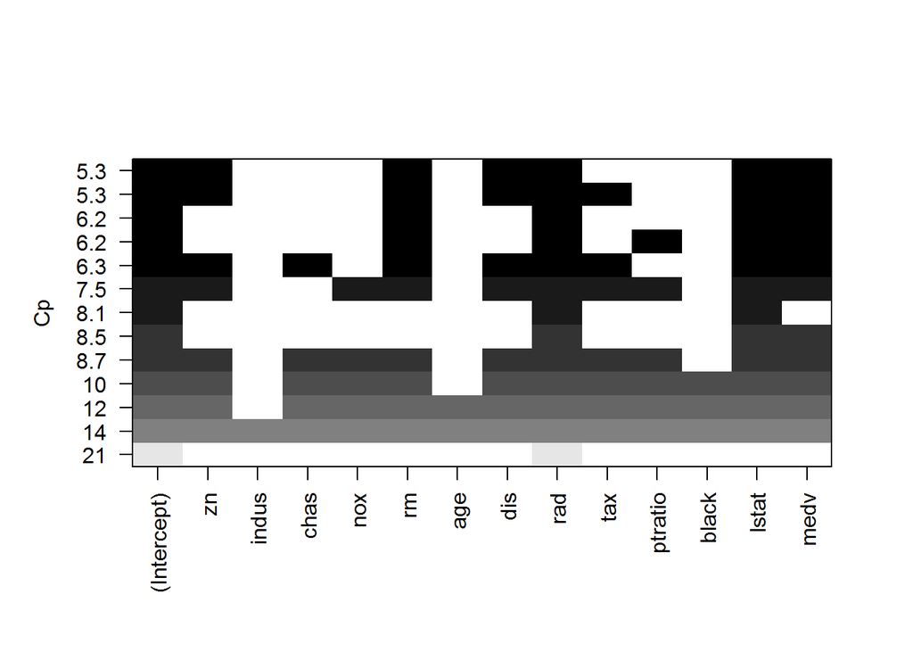

```r
plot(sub.fit ,scale ="Cp")
```

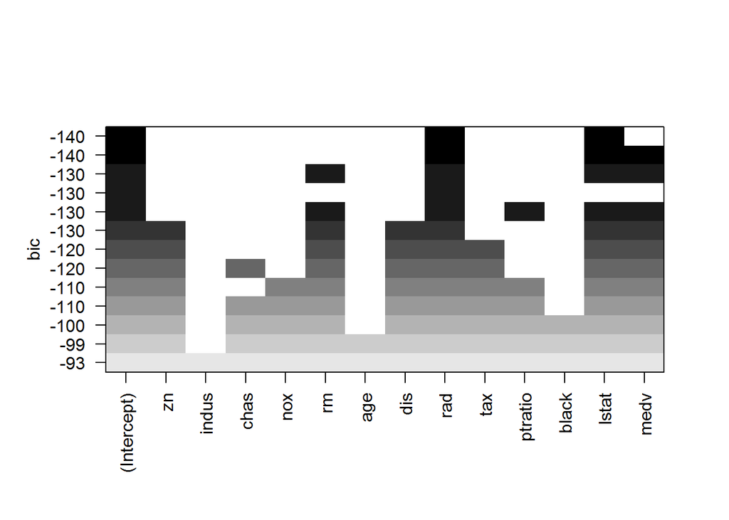

```r
plot(sub.fit ,scale ="bic")
```

The model with lowest BIC is the model containing 2 variables, including: rad and lstat. Given medv is the third one which had significant effect on the outcome in the linear regression, it could be included as well.

```r
linear <- lm(crim~rad+lstat+medv,data=Boston)
summary(linear)
```

```
##
## Call:
## lm(formula = crim ~ rad + lstat + medv, data = Boston)
##
## Residuals:
##    Min     1Q Median     3Q    Max
## -9.026 -1.855 -0.351  1.077 76.098
##
## Coefficients:
##             Estimate Std. Error t value Pr(>|t|)
## (Intercept) -1.46489    1.73081  -0.846   0.3978
## rad          0.52034    0.03836  13.564   <2e-16 ***
## lstat        0.15871    0.06404   2.478   0.0135 *
## medv        -0.08426    0.04693  -1.795   0.0732 .
## ---
## Signif. codes:  0 '***' 0.001 '**' 0.01 '*' 0.05 '.' 0.1 ' ' 1
##
## Residual standard error: 6.545 on 502 degrees of freedom
## Multiple R-squared:  0.4245, Adjusted R-squared:  0.4211
## F-statistic: 123.4 on 3 and 502 DF,  p-value: < 2.2e-16
```

```r
mean((test$crim - predict.lm(linear, test)) ^ 2)
```

```
## [1] 35.8701
```

3. Ridge regression

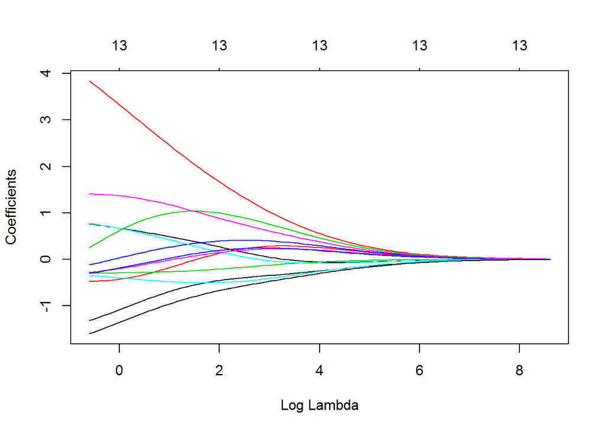

```r
set.seed(666)
library(glmnet)

x <- model.matrix(crim ~ ., train)[,-1]
x.test <- model.matrix(crim ~ ., test)[,-1]
y <- train$crim
x <- scale(x)

ridge.mod <- glmnet(x, y, alpha=0)

plot(ridge.mod, xvar='lambda')
```

```r
## cross-validation
cv.out <- cv.glmnet(x, y, alpha=0, lambda=exp(seq(0, 20, 0.05)))

ridge.pred <- predict(ridge.mod, s=cv.out$lambda.min, newx=x.test) # prediction
mean((ridge.pred -test$crim)^2)
```

```
## [1] 107894.9
```

Turns out ridge is not a good method.

4. LASSO

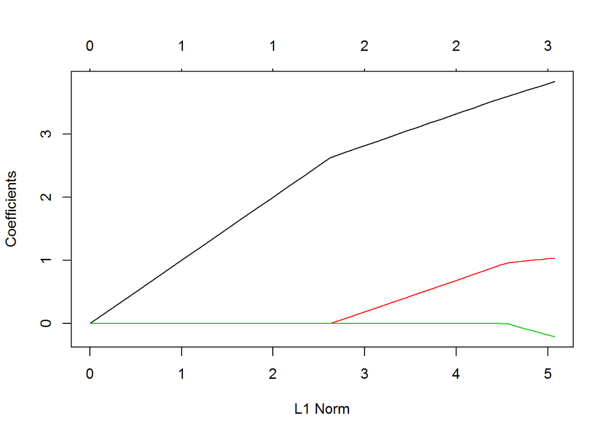

```r
set.seed(666)
lasso.mod <-glmnet (x,y,alpha =1, lambda =exp(seq(0, 20, 0.05)))
plot(lasso.mod)
```

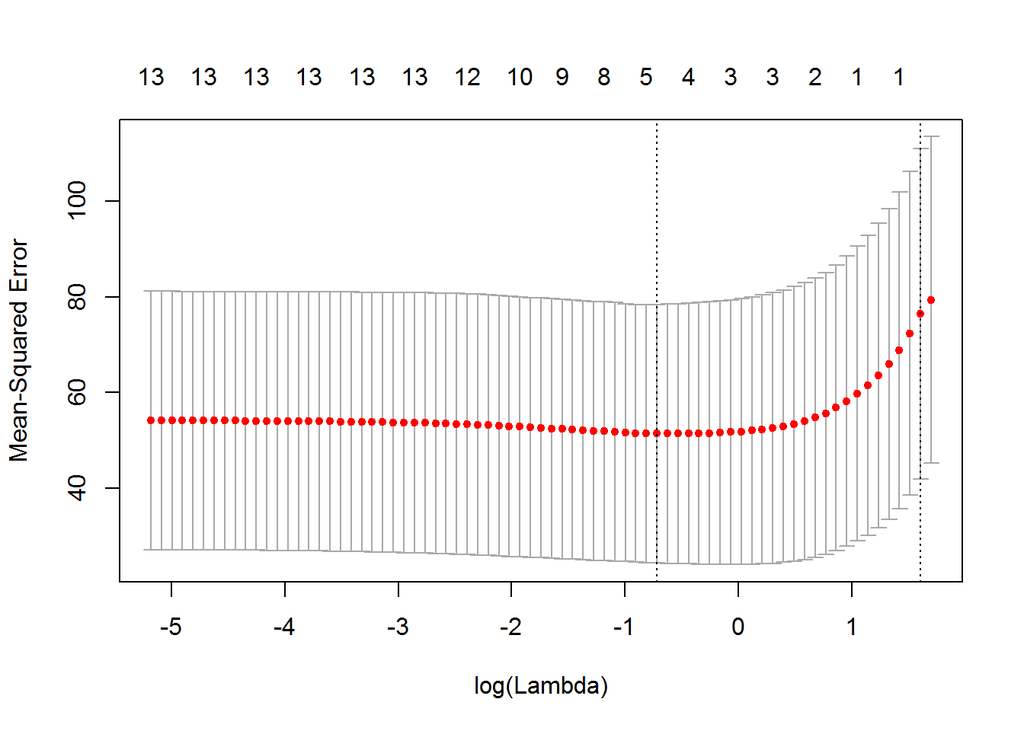

```r
cv.out <- cv.glmnet (x,y,alpha =1)
plot(cv.out)
```

```r
bestlam <- cv.out$lambda.min
lasso.pred <- predict(lasso.mod,s=bestlam ,newx=x.test)
mean((lasso.pred-test$crim)^2)
```

```
## [1] 3500.728
```

```r
out<-glmnet(x,y,alpha =1, lambda =exp(seq(0, 20, 0.05)))
lasso.coef=predict(out ,type ="coefficients",s=bestlam )[1:14,]
lasso.coef
```

```
## (Intercept)          zn       indus        chas         nox          rm
##   3.3878523   0.0000000   0.0000000   0.0000000   0.0000000   0.0000000
##         age         dis         rad         tax     ptratio       black
##   0.0000000   0.0000000   3.8280900   0.0000000   0.0000000   0.0000000
##       lstat        medv
##   1.0382345  -0.2093601
```

```r
sum(lasso.coef!=0)
```

```
## [1] 4
```

It gives very similar results as from best subset: rad, lstat and medv. It also verifed that my choice of the third predictor medv was a good choice.

5. PCR

```r
library(pls)
set.seed (666)
pcr.fit<-pcr(crim~., data=train ,scale=TRUE ,validation ="CV")
summary(pcr.fit)
```

```
## Data:    X dimension: 300 13
##  Y dimension: 300 1
## Fit method: svdpc
## Number of components considered: 13
##
## VALIDATION: RMSEP
## Cross-validated using 10 random segments.
##        (Intercept)  1 comps  2 comps  3 comps  4 comps  5 comps  6 comps
## CV           8.951    7.600    7.610    7.229    7.230    7.295    7.306
## adjCV        8.951    7.596    7.605    7.221    7.223    7.283    7.293
##        7 comps  8 comps  9 comps  10 comps  11 comps  12 comps  13 comps
## CV       7.256    7.135    7.180     7.200     7.141     7.174     7.083
## adjCV    7.242    7.119    7.164     7.184     7.121     7.153     7.062
##
## TRAINING: % variance explained
##       1 comps  2 comps  3 comps  4 comps  5 comps  6 comps  7 comps
## X       47.88    60.22    69.42    76.52    82.73    87.67    91.19
## crim    29.12    29.28    36.65    37.05    37.15    37.71    38.71
##       8 comps  9 comps  10 comps  11 comps  12 comps  13 comps
## X       93.49    95.43     97.07     98.41     99.50    100.00
## crim    40.90    40.95     41.14     42.22     42.37     43.84
```

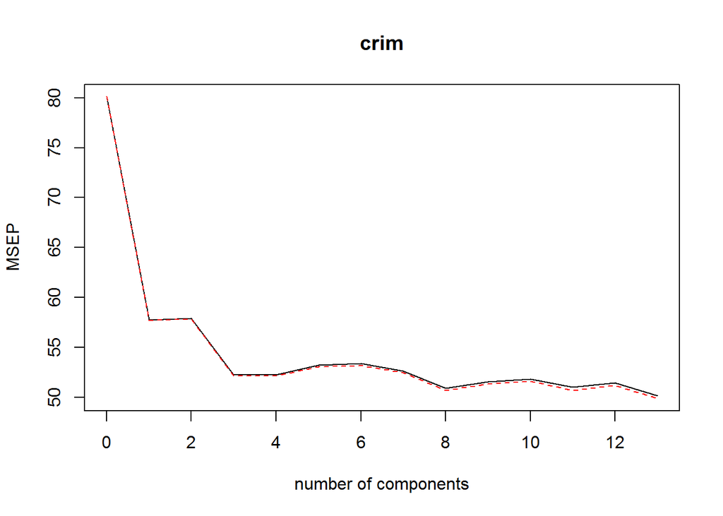

```r
validationplot(pcr.fit ,val.type="MSEP")
```

```r
pcr.pred <- predict(pcr.fit, x.test, ncomp =8)
mean((pcr.pred -test$crim)^2)
```

```
## [1] 36.05475
```